# CHAPTER A5

# 梁 - せん断力と曲げモーメント

## A5.1 はじめに

一般に、その長手方向に垂直な荷重を支持する構造部材を梁（ビーム）と呼ぶ。航空機の構造は、主翼や胴体など、梁ユニットの優れた例を提供している。主要な航空機構造ユニットに曲げ力のみが単独で作用することは極めて稀であり、軸力やねじり力が伴うのが普通である。しかしながら、曲げ力および梁の曲げによって生じる結果としての梁応力は、通常、梁構造の設計において最も重要である。

## A5.2 静定梁および不静定梁

梁は、既知の外力荷重と未知の支持反力を受けていると考えることができる。もし、加えられた既知の荷重の支持反力への分配が、静的釣合い条件のみ（すなわち、力とモーメントの総和がゼロ）から決定できる場合、その梁は「静定梁」とみなされる。しかし、既知の加えられた荷重の支持梁反力への分配が、荷重負荷時の梁材料の挙動に影響を受ける場合、支持反力は静的釣合い方程式のみからは求めることができず、その梁は「不静定梁」に分類される。このような梁を解くには、静的釣合い方程式と組み合わせて、梁の変形に基づく他の物理的条件を使用しなければならない。

## A5.3 せん断力と曲げモーメント

与えられた梁は、ある特定の既知の荷重を受けている。梁を静的釣合い状態に保つための梁の反力は、静的釣合いに必要な方程式、すなわち以下によって計算される。

$\Sigma V = 0$ 、またはすべての鉛直力の代数和がゼロに等しい。

$\Sigma H = 0$ 、またはすべての水平力の代数和がゼロに等しい。

$\Sigma M = 0$ 、またはすべてのモーメントの代数和がゼロに等しい。

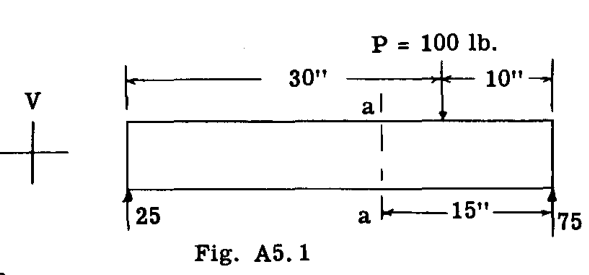

Fig. A5.1

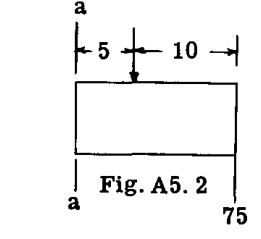

Fig. A5.2

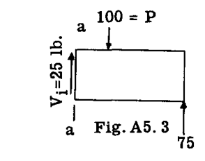

Fig. A5.3

$$\Sigma V = 75 - 100 = -25 \text{ lb.} \quad \text{--- (1)}$$

したがって、示されている力の下では、力システムは V 方向において不釣り合いであり、それゆえに V 方向の力の釣合いを生じさせるためには、断面 a-a に $25\text{ lb.}$ に等しい内部抵抗力 $V_1$ が存在していなければならない。図 A5.3 は、釣合いのために存在しなければならない抵抗せん断力 $V_1 = 25\text{ lb.}$ を示している。

図 A5.3 において $\Sigma M = 0$ を考慮し、断面 a-a 上の任意の点 O のまわりのモーメントをとると、

$$\Sigma M_O = -75 \times 15 + 100 \times 5 = -625 \text{ in.lb.} \quad \text{--- (2)}$$

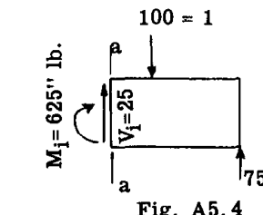

Fig. A5.4

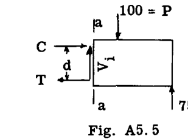

Fig. A5.5

あるいは、 $-625$ の不釣り合いモーメントは、断面 a-a のまわりに梁の部分を回転させようとする傾向がある。釣合いを提供するために、断面 a-a には反対作用を及ぼす抵抗モーメント $M_1 = 625$ が存在しなければならない。図 A5.4 は、作用している $V_1$ と $M_1$ を伴う自由体を示している。

ここで、 $\Sigma H$ はゼロに等しくなければならない。外力および内部抵抗せん断力 $V_1$ は水平成分を持たない。したがって、抵抗モーメント $M_1$ を生じさせる内部力は、不平衡な水平力を持たないようなものでなければならない。これは、抵抗モーメント $M_1$ が、図 A5.5 に示すような偶力の形で作用することを意味する。すなわち、 $M_1 = Cd$ または $Td$ であり、 $\Sigma H = 0$ とするために $T$ は $C$ に等しくなければならない。

梁に作用する荷重と反力が、梁の隣接する部分に対して一方の部分を上方または下方にせん断、あるいは移動させようとする傾向を「外的な鉛直せん断力」、または一般に「梁の鉛直せん断力」と呼び、記号 $V$ で表す。

式 (1) から、梁の任意の断面における鉛直せん断力は、せん断力を求めようとする断面の片側に作用するすべての力と反力の代数和として定義できる。断面の左側の部分が右側の部分に対して上方に移動しようとする傾向がある場合、鉛直せん断力の符号は正（プラス）とされ、その傾向が逆の場合は負（マイナス）とされる。言い換えれば、力の代数和が左側で上向き、または右側で下向きであれば鉛直せん断力は正であり、左側で下向き、右側で上向きであれば負である。

式 (2) から、梁の任意の断面における曲げモーメントは、その断面に関する、断面のいずれかの側に作用するすべての力のモーメントの代数和として定義できる。もしこの曲げモーメントが梁の上部繊維を圧縮（短縮）させ、下部繊維を引張（伸長）させる傾向がある場合、その曲げモーメントは正の曲げモーメントに分類され、逆の状態の場合は負とされる。

## A5.4 せん断力図および曲げモーメント図

航空機の設計においては、多くの梁がその高さや断面が変化するテーパー状であり、また変動する分布荷重を支持している。したがって、このような梁の様々な断面を設計またはチェックするためには、梁に沿ったすべての断面における鉛直せん断力と曲げモーメントの値の完全な全体像を持つことが必要である。これらの値を基準線からの縦座標としてプロットした場合、得られる曲線を「せん断力図」および「曲げモーメント図」と呼ぶ。学生諸君のこれらに関する知識を新たにするために、いくつかのせん断力図と曲げモーメント図の例をプロットする。

### 例題 1

図 A5.6 に示す梁のせん断力図および曲げモーメント図を描け。梁の自重は無視せよ。

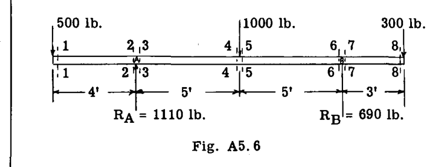

Fig. A5.6

一般に、最初のステップは反力を決定することである。  
$R_B$ を求めるために、点 A のまわりのモーメントをとる。

$$\Sigma M_A = -4 \times 500 + 1000 \times 5 + 300 \times 13 - 10R_B = 0$$

よって、 $R_B = 690\text{ lb.}$

$$\Sigma V = -500 + R_A - 1000 - 300 + 690 = 0$$

よって、 $R_A = 1110\text{ lb.}$

### せん断力図の計算：

梁の左端から開始する。  
$500\text{ lb.}$ 荷重のすぐ右側の断面、すなわち断面 1-1 を考え、その断面の左側の部分を考慮すると、1-1 における鉛直せん断力は $\Sigma V = -500$ （負、左側で下向き）となる。

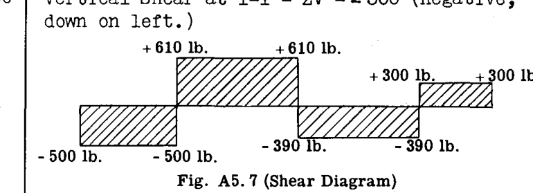

Fig. A5.7

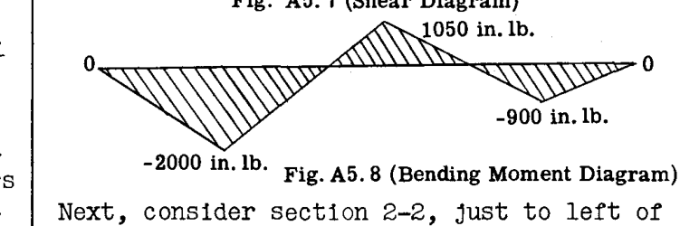

Fig. A5.8

次に、反力 $R_A$ のすぐ左側の断面 2-2 を考える。

$$\Sigma V = -500$$

、または断面 1-1 と同じ。

次に、 $R_A$ のすぐ右側の断面 3-3 を考える。

$$\Sigma V = -500 + 1110 = 610$$

（正、断面の左側で上向き）。

次に、 $1000\text{ lb.}$ 荷重のすぐ左側の断面 4-4 を考える。

$$\Sigma V = -500 + 1110 = 610$$

（断面 3-3 と同じ）。

$1000\text{ lb.}$ 荷重のすぐ右側の断面 5-5 について：

$$\Sigma V = -500 + 1110 - 1000 = -390$$

（左側で下向き）。

断面 5-5 より右側の梁の部分を自由体として用いて、このせん断力をチェックする。

$$\Sigma V = -300 + 690 = 390$$

であり、これは一致する（ $\Sigma V$ が右側で上向きであるため、符号はマイナス）。断面 6-6 について、右側の部分を自由体として使用する：

$$\Sigma V = -300 + 690 = 390$$

（マイナスせん断）。

断面 7-7：

$$\Sigma V = -300$$

（正のせん断、右側で下向き）。

断面 8-8：

$$\Sigma V = -300$$

（正のせん断）。

図 A5.7 は、せん断力図上にプロットされた値を示している。

### 曲げモーメント図の計算

断面 1-1 から開始し、左側の力のみを考慮する：

$$\Sigma M = -500 \times 0 = 0$$

断面 2-2 と 3-3 は微分量（ごくわずかな距離）しか離れていないため、 $R_A$ のすぐ上にある断面を想定し、左側の力のみを考慮する：

$$\Sigma M = -500 \times 4 = -2000 \text{ in. lb.}$$

（負のモーメント、上部繊維の引張による）。

$1000\text{ in. lb.}$ 荷重の下の断面を考慮する：  
左側のモーメントの和

$$\Sigma M_{\text{to left}} = -500 \times 9 + 1110 \times 5 = 1050 \text{ in. lb.}$$

（正のモーメント、上部繊維の圧縮）。

右側の力を考慮してチェックする：

$$\Sigma M_{\text{right}} = 300 \times 8 - 690 \times 5 = -1050 \text{ in. lb.}$$

（負のモーメント、上部繊維の引張）。

断面 8-8 において：

$$\Sigma M_{\text{right}} = 300 \times 0 = 0$$

図 A5.8 はプロットされた値を示している。

以上の結果から、ある断面の左側にある力から曲げモーメントを求める場合、時計回りのときに曲げモーメントが正になることがわかる。右側の力から求める場合は、反時計回りのときに正となる。学生は、たわんだ構造のおおよその形状をスケッチし、上部および下部繊維に引張または圧縮が存在するかどうかから符号を判断すべきである。

### 例題 2

図 A5.9 に示す梁と荷重について、せん断力図および曲げモーメント図を計算し、描け。

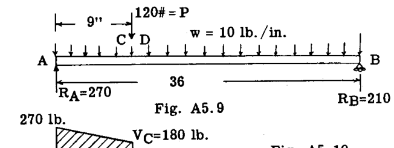

Fig. A5.9

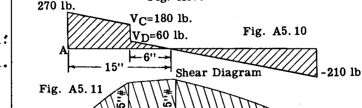

Fig. A5.10

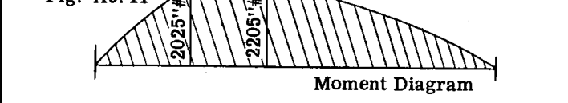

Fig. A5.11

まず、反力 $R_A$ および $R_B$ を決定する。

$$\Sigma M_A = 36 \times 10 \times 18 + 120 \times 9 - 36R_B = 0$$

よって、 $R_B = 210\text{ lb.}$

$$\Sigma V = -120 - 36 \times 10 + 210 + R_A = 0$$

よって、 $R_A = 270\text{ lb.}$

### せん断力図：

点 A における反力のすぐ右側の鉛直せん断力は、 $+270$ または正に等しい。これは図 A5.10 に直線 AE としてプロットされている。荷重のすぐ左側にある断面 C における鉛直せん断力は、断面の左側の力を考慮すると、

$$270 - 9 \times 10 = 180 \text{ lb. (上向き、または正)}$$

となる。A からの距離が $x$ である、A と C の間の任意の断面における鉛直せん断力は、

$$V_x = 270 - 10x$$

であり、したがって、せん断力は A における 270 から C における 180 まで、 $10\text{ lb./in.}$ の一定の割合で減少する。

荷重のすぐ右側にある断面 D における鉛直せん断力は、

$$V_D = \Sigma V_{\text{left}} = 270 - 10 \times 9 - 120 = 60 \text{ (上向き、または正)}$$

となる。

D と B の間の任意の断面の A からの距離を $x$ とすると、D と B の間の任意の断面における鉛直せん断力 $V_{DB}$ は、

$$V_{DB} = 270 - 120 - 10x \quad \text{--- (1)}$$

点 B （ $x = 36$ ）において、

$$V_B = 270 - 120 - 10 \times 36 = -210 \text{ lb.}$$

となり、これは反力 $R_B$ と一致する。

鉛直せん断力は D から B まで $10\text{ lb./in.}$ の割合で減少するため、D におけるせん断力が $60\text{ lb.}$ であることから、D からせん断力がゼロになる点までは $6\text{ in.}$ になる。

この点は、式 (1) をゼロに等しくし、 $x$ について解くことによっても求めることができる。

$$0 = 270 - 120 - 10x \quad \text{または} \quad x = \frac{150}{10} = 15\text{ in. (Aから)}$$

もし、せん断力図が集中荷重の下でゼロを横切っている場合、せん断力方程式をゼロに等しくして $x$ について解く方法は使用できないため、一般には、せん断力がゼロになる場所を見つけるためにせん断力図を描くのが最善である。図 A5.10 はプロットされたせん断力図を示している。

### 曲げモーメント図：

反力 $R_A$ のすぐ右側の断面 A において、左側の力を考慮すると、 $R_A$ の腕がゼロであるため、曲げモーメントはゼロである。

左側の反力 $R_A$ から距離 $x$ にある、A と C の間の任意の断面における曲げモーメントは、

$$M_x = R_A x - \frac{wx^2}{2} \quad \text{--- (2)}$$

式 (2) において、 $x$ は 9 より大きくなることはできない。

D と B の間（ $x$ が 9 より大きい）における曲げモーメントの方程式は、

$$M_x = R_A x - P(x-9) - \frac{wx^2}{2} \quad \text{--- (3)}$$

$$= 270x - 120(x-9) - \frac{10x^2}{2}$$

$$= 1080 + 150x - 5x^2 \quad \text{--- (4)}$$

断面 C （ $x = 9\text{ in.}$ ）において、式 (4) に代入すると、

$$M_C = 1080 + 150 \times 9 - 5 \times 9^2 = 2025 \text{ in. lb.}$$

（正、上部繊維の圧縮）。

せん断力がゼロになる点（ $x = 15\text{ in.}$ ）において、

$$M = 1080 + 150 \times 15 - 5 \times 15^2 = 2205$$

このように、式 (2) と (4) に代入することにより、図 A5.11 にプロットされているようなモーメント図が得られる。

## A5.5 最大曲げモーメントの断面

例題 2 の梁の曲げモーメントの一般的な表現は、式 (3) から得られる。

$$M_x = R_A x - P(x-9) - \frac{wx^2}{2}$$

ここで、 $M_x$ を極大または極小にする $x$ の値は、 $M_x$ の $x$ に関する一次導関数をゼロに等しくする値、すなわち、

$$\frac{dM_x}{dx} = R_A - P - wx \quad \text{--- (5)}$$

したがって、 $M_x$ を極大または極小にする $x$ の値は、次の方程式から求めることができる。

$$R_A - P - wx = 0$$

しかし、この方程式を観察すると、項 $R_A - P - wx$ は、左側反力から距離 $x$ の断面におけるせん断力であることがわかる。したがって、せん断力がゼロのところで曲げモーメントは最大になる。したがって、せん断力がゼロの場所を示すせん断力図は、最大曲げモーメントの点を見つけるための便利な手段である。

## A5.6 せん断力と曲げモーメントの関係

式 (5) の右辺はせん断力に等しいため、式 (5) は以下のように書くこともできる。

$$\frac{dM}{dx} = V$$

したがって、

$$dM = Vdx \quad \text{--- (6)}$$

これは、距離 $dx$ だけ離れた2つの断面における曲げモーメントの差 $dM$ が、2つの断面間のせん断曲線の下の面積 $Vdx$ に等しいことを意味する。したがって、2つの断面 $x_1$ と $x_2$ について、

$$\int_{M_1}^{M_2} dM = \int_{x_1}^{x_2} Vdx$$

このように、せん断力図上の任意の2点間の面積は、これら2点間の曲げモーメントの変化量に等しい。

この関係を説明するために、例題 2 のせん断力図（図 A5.10）を考える。左側反力 $R_A$ と荷重の間の曲げモーメントの変化は、これら2点間のせん断力図の面積に等しく、すなわち、

$$\frac{270 + 180}{2} \times 9 = 2025 \text{ in. lb.}$$

左側支持点における曲げモーメントはゼロであるため、この変化は、荷重 P の下の断面における真のモーメントに等しくなる。

これに、点 D とせん断力ゼロの点との間の小さな三角形の面積、すなわち $\frac{60}{2} \times 6 = 180$ を加えると、最大モーメントとして $2205 \text{ in. lb.}$ を得る。これは、せん断力ゼロの点と点 B との間のせん断力図の面積をとることによってチェックできる。

$$\frac{210}{2} \times 21 = 2205 \text{ in. lb.}$$

### 例題 3

図 A5.12 は、ストラット BD および CE によって支持されたランディングギアのオレオストラット ADEO を示している。 $15000\text{ lb.}$ の着陸接地荷重が、示されているように車軸を通して作用している。すべての部材の軸力、およびオレオストラットのせん断力と曲げモーメント図を求めよ。

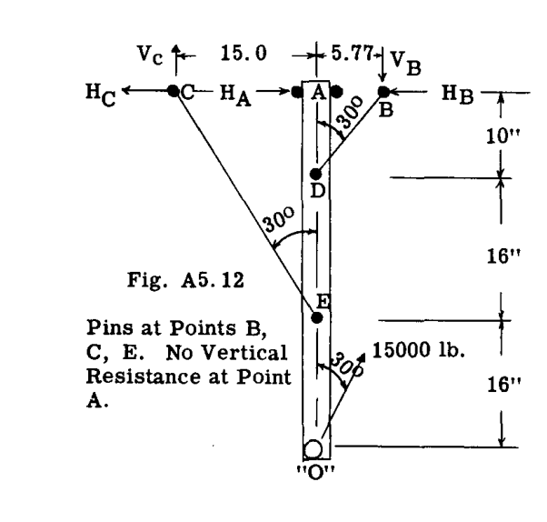

Fig. A5.12

### 解法：

$V_C$ を求めるために、点 B のまわりのモーメントをとる。

$$\Sigma M_B = -15000 \times 0.5 \times 42 + 15000 \times 0.866 \times 5.77 + 20.77 V_C = 0$$

よって、 $V_C = 11550 \text{ lb.}$